# Data 607 - Project 2

SG

```r
library(magrittr)
library(stringr)
library(dplyr)
library(tidyr)
library(zoo)
```

```r
library(ggplot2)
library(knitr)
library(DT)
```

# Project 2 - Perform analysis on wide data sets

We will analyze three different wide data sets:  
1. Salaries by College Type - https://www.kaggle.com/wsj/college-salaries/version/1#salaries-by-college-type.csv This was found from the discussion board, post title: Salaries by College Degree/Type/Region  
2. Graduate Admissions - https://www.kaggle.com/mohansacharya/graduate-admissions This was a data set I found on my own.  
3. Employee Reviews - https://www.kaggle.com/petersunga/google-amazon-facebook-employee-reviews This was found the from the discussion board, post title: Employee Reviews at top tech companies  
These data sets have a large amount of data, so we will take sample of n size = 200, from each data set.

## Salaries by College Type

We will analyze salaries by college type. It will be interesting to see how the college type is correlated with salaries, at: 1. Mid Career Median Salaries by College Type and by Percentiles 2. Starting Salaries by College Type

### Sample the Raw Data

We get the sample of raw data for Salaries by College Type.

```r
collegeTypeData <- read.csv("Data/salaries-by-college-type.csv")
collegeTypeDf <- sample_n(collegeTypeData, 200)
#collegeTypeDf <- na.omit(collegeTypeDf)
datatable(collegeTypeDf, options = list(pageLength = 5))
```

|  | School.Name | School.Type | Starting.Median.Salary | Mid.Career.Median.Salary | Mid.Career.10th.Percentile.Salary | Mid.Career.25th.Percentile.Salary | Mid.Career.75th.Percentile.Salary | Mid.Career.90th.Percentile.Salary |
| --- | --- | --- | --- | --- | --- | --- | --- | --- |
| 1 | University of Massachusetts (UMass) - Lowell | State | $45,400.00 | $86,600.00 | $50,900.00 | $65,000.00 | $113,000.00 | $158,000.00 |
| 2 | Bowdoin College | Liberal Arts | $48,100.00 | $107,000.00 | N/A | $74,600.00 | $146,000.00 | N/A |
| 3 | San Jose State University (SJSU) | State | $53,500.00 | $95,600.00 | $50,700.00 | $70,500.00 | $122,000.00 | $156,000.00 |
| 4 | Washington and Lee University | Liberal Arts | $53,600.00 | $104,000.00 | N/A | $82,800.00 | $146,000.00 | N/A |
| 5 | Eastern Washington University | State | $38,600.00 | $70,900.00 | $36,000.00 | $50,500.00 | $93,100.00 | $117,000.00 |
| 6 | University of Wyoming (UW) | State | $44,500.00 | $78,700.00 | $41,500.00 | $54,000.00 | $105,000.00 | $145,000.00 |
| 7 | State University of New York (SUNY) at Farmingdale | State | $47,300.00 | $84,200.00 | $50,200.00 | $59,800.00 | $110,000.00 | $162,000.00 |
| 8 | California State University, East Bay (CSUEB) | State | $49,200.00 | $84,300.00 | $46,000.00 | $62,400.00 | $115,000.00 | $155,000.00 |
| 9 | Colorado College (CC) | Liberal Arts | $38,500.00 | $81,400.00 | N/A | $43,000.00 | $148,000.00 | N/A |
| 10 | University of California at Los Angeles (UCLA) | State | $52,600.00 | $101,000.00 | $51,300.00 | $72,500.00 | $139,000.00 | $193,000.00 |

[output cut: 190 more lines]

### Reduce width of data

We reduce the width of the data. The following columns make the data set wide:  
* Mid-Career 10th Percentile Salary  
* Mid-Career 25th Percentile Salary  
* Mid-Career 75th Percentile Salary  
* Mid-Career 90th Percentile Salary  
We transform these columns into two different columns: MidCareerMedianPercentile and PercentileSalary, to view salaries by their Mid Career Median Percentiles. We also reduce the string in the MidCareerMedianPercentile column to a number. The data is now cleaner to analyze:

```r
# Reduce width of Percentile columns
collegeTypeDf <- collegeTypeDf %>% gather(key = MidCareerMedianPercentile, value = PercentileSalary, Mid.Career.10th.Percentile.Salary:Mid.Career.90th.Percentile.Salary)
collegeTypeDf[collegeTypeDf == "N/A"]  <- 0

# Convert all Salary columns from string to numeric types
collegeTypeDf$Starting.Median.Salary <- as.numeric(gsub('[$,]', '', collegeTypeDf$Starting.Median.Salary))
collegeTypeDf$Mid.Career.Median.Salary <- as.numeric(gsub('[$,]', '', collegeTypeDf$Mid.Career.Median.Salary))
collegeTypeDf$PercentileSalary <- as.numeric(gsub('[$,]', '', collegeTypeDf$PercentileSalary))

# Apply regex to get Percentile numbers
collegeTypeDf$MidCareerMedianPercentile <- sub("Mid.Career.", "\\1", collegeTypeDf$MidCareerMedianPercentile)
collegeTypeDf$MidCareerMedianPercentile <- sub(".Percentile.Salary", "\\1", collegeTypeDf$MidCareerMedianPercentile)

datatable(collegeTypeDf, options = list(pageLength = 5))
```

|  | School.Name | School.Type | Starting.Median.Salary | Mid.Career.Median.Salary | MidCareerMedianPercentile | PercentileSalary |
| --- | --- | --- | --- | --- | --- | --- |
| 1 | University of Massachusetts (UMass) - Lowell | State | 45400 | 86600 | 10th | 50900 |
| 2 | Bowdoin College | Liberal Arts | 48100 | 107000 | 10th | 0 |
| 3 | San Jose State University (SJSU) | State | 53500 | 95600 | 10th | 50700 |
| 4 | Washington and Lee University | Liberal Arts | 53600 | 104000 | 10th | 0 |
| 5 | Eastern Washington University | State | 38600 | 70900 | 10th | 36000 |
| 6 | University of Wyoming (UW) | State | 44500 | 78700 | 10th | 41500 |
| 7 | State University of New York (SUNY) at Farmingdale | State | 47300 | 84200 | 10th | 50200 |
| 8 | California State University, East Bay (CSUEB) | State | 49200 | 84300 | 10th | 46000 |
| 9 | Colorado College (CC) | Liberal Arts | 38500 | 81400 | 10th | 0 |
| 10 | University of California at Los Angeles (UCLA) | State | 52600 | 101000 | 10th | 51300 |

[output cut: 790 more lines]

### Analysis

**1. What was the average salary for each Median Career Percentile?**

```r
avgByPercentile <- aggregate(x=collegeTypeDf$PercentileSalary,
          by=list(collegeTypeDf$School.Type,collegeTypeDf$MidCareerMedianPercentile),
          FUN=mean)
colnames(avgByPercentile) <- c("CollegeType", "MidCareerMedianPercentile", "AverageSalary")
datatable(avgByPercentile, options = list(pageLength = 5))
```

|  | CollegeType | MidCareerMedianPercentile | AverageSalary |
| --- | --- | --- | --- |
| 1 | Engineering | 10th | 50426.6666666667 |
| 2 | Ivy League | 10th | 58185.7142857143 |
| 3 | Liberal Arts | 10th | 12827.027027027 |
| 4 | Party | 10th | 42100 |
| 5 | State | 10th | 41653.6 |
| 6 | Engineering | 25th | 80813.3333333333 |
| 7 | Ivy League | 25th | 83300 |
| 8 | Liberal Arts | 25th | 63291.8918918919 |
| 9 | Party | 25th | 60931.25 |
| 10 | State | 25th | 56560 |

[output cut: 10 more lines]

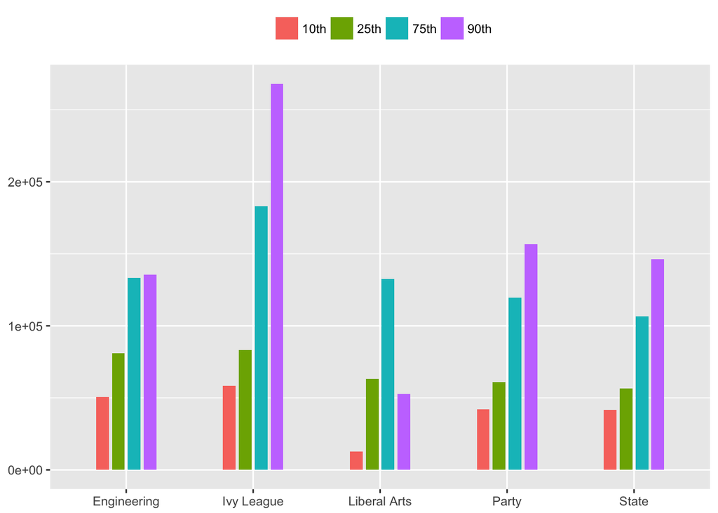

```r
ggplot(avgByPercentile, aes(CollegeType, AverageSalary)) + geom_bar(aes(fill = MidCareerMedianPercentile),
   width = 0.4, position = position_dodge(width=0.5), stat="identity") +
   theme(legend.position="top", legend.title =
   element_blank(),axis.title.x=element_blank(),
   axis.title.y=element_blank())
```

**Analyzing Starting Salaries**  
**College Types with Starting Salaries > $60,000**

Here, we see only Engineering and Ivy League schools with starting salaries above $60,000.

```r
#collegeTypeDf$Starting.Median.Salary <- as.numeric(collegeTypeDf$Starting.Median.Salary)
greaterThanSixtyK<- collegeTypeDf %>% select(School.Name, School.Type, Starting.Median.Salary) %>% filter(Starting.Median.Salary > 60000)
datatable(greaterThanSixtyK, options = list(pageLength = 5))
```

|  | School.Name | School.Type | Starting.Median.Salary |
| --- | --- | --- | --- |
| 1 | Massachusetts Institute of Technology (MIT) | Engineering | 72200 |
| 2 | Harvey Mudd College | Engineering | 71800 |
| 3 | Rensselaer Polytechnic Institute (RPI) | Engineering | 61100 |
| 4 | Stevens Institute of Technology | Engineering | 60600 |
| 5 | Worcester Polytechnic Institute (WPI) | Engineering | 61000 |
| 6 | Princeton University | Ivy League | 66500 |
| 7 | Polytechnic University of New York, Brooklyn | Engineering | 62400 |
| 8 | Cooper Union | Engineering | 62200 |
| 9 | Harvard University | Ivy League | 63400 |
| 10 | Cornell University | Ivy League | 60300 |

[output cut: 30 more lines]

Here we see a bar plot of the above table. Engineering schools are displayed to have higher starting salaries than Ivy League schools.

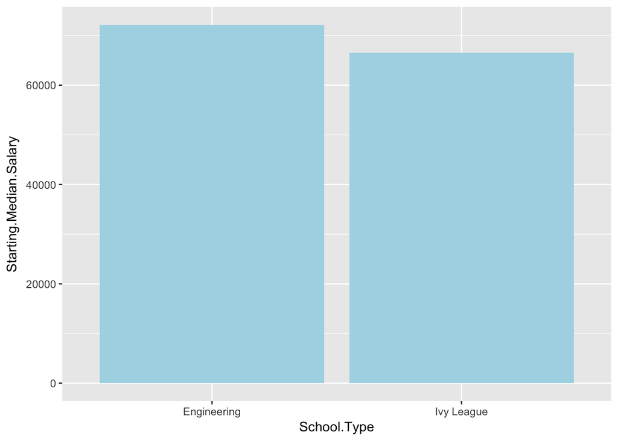

```r
ggplot(data = greaterThanSixtyK, aes(x = School.Type, y = Starting.Median.Salary)) +
       geom_bar(stat = 'identity', position = 'dodge', fill="LightBlue")
```

## Graduate Admissions

We will analyze graduate admissions using by: * Letters of Recommendation and State of Purpose by Chances of Admission

### Sample the Raw Data

We get the sample of raw data for Graduate Admissions.

```r
admissionsData <- read.csv("Data/Admission_Predict.csv")
admissionsDf <- sample_n(admissionsData, 200)
datatable(admissionsDf, options = list(pageLength = 5))
```

|  | Serial.No. | GRE.Score | TOEFL.Score | University.Rating | SOP | LOR | CGPA | Research | Chance.of.Admit |
| --- | --- | --- | --- | --- | --- | --- | --- | --- | --- |
| 1 | 174 | 323 | 113 | 4 | 4 | 4.5 | 9.23 | 1 | 0.89 |
| 2 | 281 | 311 | 102 | 3 | 4.5 | 4 | 8.64 | 1 | 0.68 |
| 3 | 216 | 330 | 116 | 5 | 5 | 4.5 | 9.36 | 1 | 0.93 |
| 4 | 104 | 317 | 104 | 2 | 4.5 | 4 | 8.47 | 0 | 0.57 |
| 5 | 375 | 315 | 105 | 2 | 2 | 2.5 | 7.65 | 0 | 0.39 |
| 6 | 225 | 305 | 105 | 2 | 3 | 2 | 8.23 | 0 | 0.67 |
| 7 | 107 | 329 | 111 | 4 | 4.5 | 4.5 | 9.18 | 1 | 0.87 |
| 8 | 245 | 314 | 107 | 2 | 2.5 | 4 | 8.56 | 0 | 0.63 |
| 9 | 30 | 310 | 99 | 2 | 1.5 | 2 | 7.3 | 0 | 0.54 |
| 10 | 316 | 308 | 104 | 2 | 2.5 | 3 | 8.07 | 0 | 0.65 |

[output cut: 190 more lines]

### Reduce width of data

We reduce the width of the data by: 1. Combining columns of Letter of Recommendation and State of Purpose, and a separate column for their values. We can combine these two columns because they’re both based on a rating system of out of 5.

```r
admissionsDf <- admissionsDf %>% gather(key = LetterType, value = LetterStrength, SOP:LOR)
admissionsDf$Chance.of.Admit <- as.numeric(admissionsDf$Chance.of.Admit)
admissionsDf$LetterStrength <- as.numeric(admissionsDf$LetterStrength)
datatable(admissionsDf, options = list(pageLength = 5))
```

|  | Serial.No. | GRE.Score | TOEFL.Score | University.Rating | CGPA | Research | Chance.of.Admit | LetterType | LetterStrength |
| --- | --- | --- | --- | --- | --- | --- | --- | --- | --- |
| 1 | 174 | 323 | 113 | 4 | 9.23 | 1 | 0.89 | SOP | 4 |
| 2 | 281 | 311 | 102 | 3 | 8.64 | 1 | 0.68 | SOP | 4.5 |
| 3 | 216 | 330 | 116 | 5 | 9.36 | 1 | 0.93 | SOP | 5 |
| 4 | 104 | 317 | 104 | 2 | 8.47 | 0 | 0.57 | SOP | 4.5 |
| 5 | 375 | 315 | 105 | 2 | 7.65 | 0 | 0.39 | SOP | 2 |
| 6 | 225 | 305 | 105 | 2 | 8.23 | 0 | 0.67 | SOP | 3 |
| 7 | 107 | 329 | 111 | 4 | 9.18 | 1 | 0.87 | SOP | 4.5 |
| 8 | 245 | 314 | 107 | 2 | 8.56 | 0 | 0.63 | SOP | 2.5 |
| 9 | 30 | 310 | 99 | 2 | 7.3 | 0 | 0.54 | SOP | 1.5 |
| 10 | 316 | 308 | 104 | 2 | 8.07 | 0 | 0.65 | SOP | 2.5 |

[output cut: 390 more lines]

### Analysis

#### Statement of Purpose and Letters of Recommendation by Chances of Admission

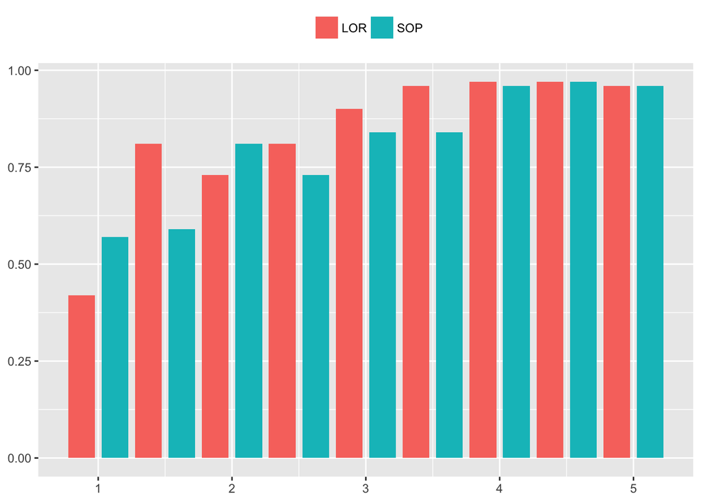

```r
ggplot(admissionsDf, aes(LetterStrength, Chance.of.Admit)) + geom_bar(aes(fill = LetterType),
   width = 0.4, position = position_dodge(width=0.5), stat="identity") +
   theme(legend.position="top", legend.title =
   element_blank(),axis.title.x=element_blank(),
   axis.title.y=element_blank())
```

Below we see the that the average strengths of Letters of Recommendations and Statements of Purpose seemed to be almost the same.

```r
aggregAdmissions <- aggregate(x=admissionsDf$LetterStrength,
          by=list(admissionsDf$LetterType),
          FUN=mean)
colnames(aggregAdmissions) <- c("Letter Type", "Letter Strength")
datatable(aggregAdmissions)
```

|  | Letter Type | Letter Strength |
| --- | --- | --- |
| 1 | LOR | 3.5275 |
| 2 | SOP | 3.43 |

#### Chance of Admission by GPA

Below we observe the Chance of Admission vs. GPA. We see an overall positive linear correlation between the Chance of Admission and GPA, which makes sense.

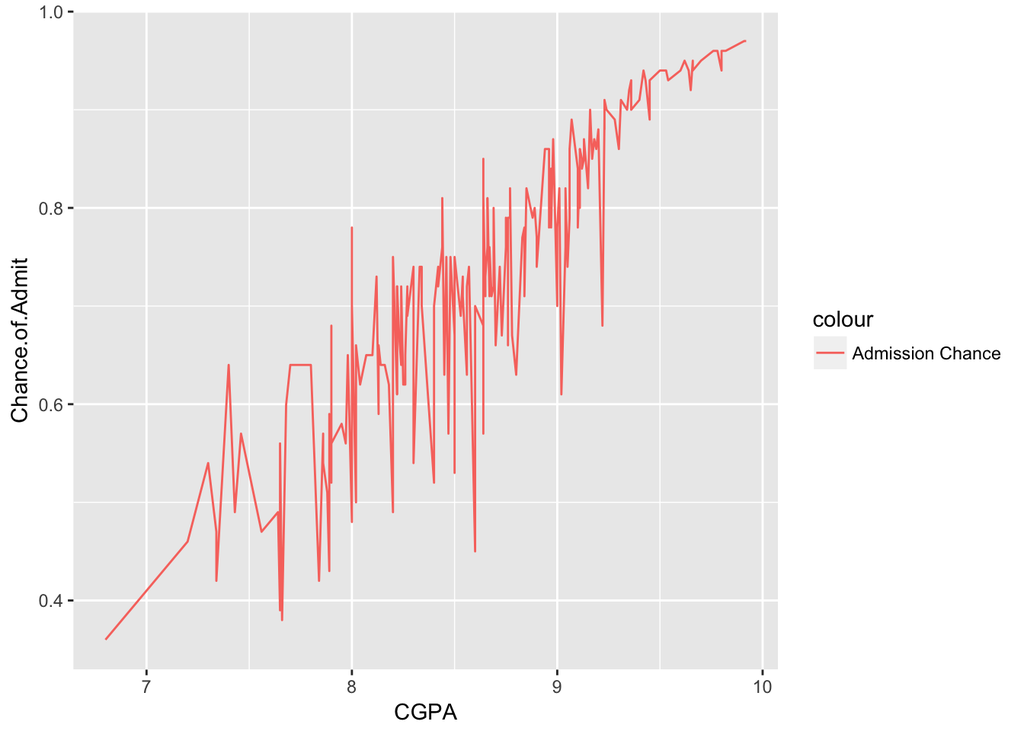

```r
ggplot(admissionsDf, aes(CGPA)) +
  geom_line(aes(y = Chance.of.Admit, colour = "Admission Chance"))
```

## Employee Reviews

### Sample the Raw Data

We get the sample of raw data for Employee Reviews.

```r
emplReviewData <- read.csv("Data/employee_reviews.csv")
emplReviewDf <- sample_n(emplReviewData, 200)
datatable(emplReviewDf, options = list(pageLength = 5))
```

|  | X | company | location | dates | job.title | summary | pros | cons | advice.to.mgmt | overall.ratings | work.balance.stars | culture.values.stars | carrer.opportunities.stars | comp.benefit.stars | senior.mangemnet.stars | helpful.count | link |
| --- | --- | --- | --- | --- | --- | --- | --- | --- | --- | --- | --- | --- | --- | --- | --- | --- | --- |
| 1 | 66869 | microsoft | Bengaluru (India) | Jun 26, 2012 | Current Employee - Manager | Best Company in the World | Love the Work Culture , Love the Perks , Management Principles | We deal with a lot of North American Customers and that requires a majority of us to work in Night Shifts . Cant complain about that tough :) | none | 5 | 5.0 | 5.0 | 5.0 | 5.0 | 5.0 | 1 | https://www.glassdoor.com/Reviews/Microsoft-Reviews-E1651_P1732.htm |
| 2 | 40851 | apple | none | Jun 5, 2016 | Current Employee - Anonymous Employee | Great Culture | Challenging .. Rewarding .. Out of the Ordinary | Not for everyone out there .. Making great products isn't that easy | Keep up the culture! | 5 | 3.0 | 5.0 | 4.0 | 4.0 | 4.0 | 0 | https://www.glassdoor.com/Reviews/Apple-Reviews-E1138_P424.htm |
| 3 | 10432 | amazon | Gilbert, AZ | Jun 4, 2018 | Former Employee - Sortation Associate | Lots of Physical Work - Good Benefits | Fantastic break room Easy to move up Cool management Good money Easy work During peak (winter) you can win lots of cool prizes- including TV’s and tablets | Lots of physical work Management doesn’t listen very well sometimes Management is ALWAYS changing and moving around Music too loud Employees make messes/are terrible at their jobs and it never gets fi… | Start managing your employees better. When you say you’re going to make a change, actually go through with it. Start paying more attention to and fire the people who come in drunk. | 3 | 3.0 | 3.0 | 4.0 | 5.0 | 3.0 | 0 | https://www.glassdoor.com/Reviews/Amazon-Reviews-E6036_P262.htm |
| 4 | 63952 | microsoft | none | Oct 16, 2016 | Current Employee - Anonymous Employee | Good company | Microsoft is one of the best foreign companies in China. The work here is creatively, the pressure is not so high | The salary is not comparable with the best local internet companies such as tencent and alibaba. Typical big company problems | Listen to the user, don't pretend you know the user | 4 | 4.0 | 4.0 | 4.0 | 3.0 | 4.0 | 0 | https://www.glassdoor.com/Reviews/Microsoft-Reviews-E1651_P1440.htm |
| 5 | 63019 | microsoft | London, England (UK) | Oct 7, 2017 | Current Employee - Human Resources Manager | HR Manager | great people - caring, supportive, collaborative, driven, smart, fun | location (tough to attract diverse talent to Reading) | Invest in an office in London | 4 | 3.0 | 5.0 | 4.0 | 3.0 | 3.0 | 0 | https://www.glassdoor.com/Reviews/Microsoft-Reviews-E1651_P1346.htm |
| 6 | 27370 | amazon | Munich, Bayern (Germany) | May 27, 2018 | Current Employee - Brand Specialist | Working Amazon | Always something to learn competitive wage in Munich | Long Work hours Limited perks at work | none | 5 | 3.0 | 5.0 | 5.0 | 5.0 | 5.0 | 0 | https://www.glassdoor.com/Reviews/Amazon-Reviews-E6036_P1960.htm |
| 7 | 30289 | amazon | none | Jun 7, 2017 | Current Employee - Anonymous Employee | Amazon Review | Was a good experience working here will recommend to friends and others | Bad work life balance here | none | 4 | none | none | none | none | none | 0 | https://www.glassdoor.com/Reviews/Amazon-Reviews-E6036_P2251.htm |
| 8 | 871 | google | none | Nov 5, 2017 | Former Employee - Information Technology Resident | Great Opportunity | Many resources available to you | Repetitive work, can get boring | none | 5 | none | none | none | none | none | 0 | https://www.glassdoor.com/Reviews/Google-Reviews-E9079_P88.htm |
| 9 | 3876 | google | Mountain View, CA | Apr 8, 2014 | Current Employee - Software Engineer III | very good company | very good company to work with. | too much push and stress. | none | 5 | 5.0 | 5.0 | 5.0 | 5.0 | 5.0 | 0 | https://www.glassdoor.com/Reviews/Google-Reviews-E9079_P388.htm |
| 10 | 46460 | apple | Columbus, OH | Dec 28, 2008 | Current Employee - Mac Genius | great job | other than the discount... getting to work with cool tech and a great company | being asked tech questions all the time | mostly good management | 5 | 5.0 | none | 4.5 | 5.0 | 5.0 | 0 | https://www.glassdoor.com/Reviews/Apple-Reviews-E1138_P985.htm |

[output cut: 190 more lines]

### Reduce width of the data

There are several columns for ratings, that are measured 1-5:  
* Work/Life Balance Rating  
* Culture and Values Rating  
* Career Opportunities Rating  
* Comp & Benefits Rating  
* Senior Management Rating

These columns are repetitive. So we clean this data by combining these columns into a column called RatingType and a column for each value called Rating.

```r
emplReviewDf <- emplReviewDf %>% gather(key = RatingType, value = Rating, 11:15)
emplReviewDf$overall.ratings <- as.numeric(emplReviewDf$overall.ratings)
emplReviewDf$Rating <- gsub("[[:space:]]*","0",emplReviewDf$Rating)
emplReviewDf$Rating <- as.numeric(emplReviewDf$Rating)
datatable(emplReviewDf)
```

|  | X | company | location | dates | job.title | summary | pros | cons | advice.to.mgmt | overall.ratings | helpful.count | link | RatingType | Rating |
| --- | --- | --- | --- | --- | --- | --- | --- | --- | --- | --- | --- | --- | --- | --- |
| 1 | 66869 | microsoft | Bengaluru (India) | Jun 26, 2012 | Current Employee - Manager | Best Company in the World | Love the Work Culture , Love the Perks , Management Principles | We deal with a lot of North American Customers and that requires a majority of us to work in Night Shifts . Cant complain about that tough :) | none | 5 | 1 | https://www.glassdoor.com/Reviews/Microsoft-Reviews-E1651_P1732.htm | work.balance.stars | 50 |
| 2 | 40851 | apple | none | Jun 5, 2016 | Current Employee - Anonymous Employee | Great Culture | Challenging .. Rewarding .. Out of the Ordinary | Not for everyone out there .. Making great products isn't that easy | Keep up the culture! | 5 | 0 | https://www.glassdoor.com/Reviews/Apple-Reviews-E1138_P424.htm | work.balance.stars | 30 |
| 3 | 10432 | amazon | Gilbert, AZ | Jun 4, 2018 | Former Employee - Sortation Associate | Lots of Physical Work - Good Benefits | Fantastic break room Easy to move up Cool management Good money Easy work During peak (winter) you can win lots of cool prizes- including TV’s and tablets | Lots of physical work Management doesn’t listen very well sometimes Management is ALWAYS changing and moving around Music too loud Employees make messes/are terrible at their jobs and it never gets fi… | Start managing your employees better. When you say you’re going to make a change, actually go through with it. Start paying more attention to and fire the people who come in drunk. | 3 | 0 | https://www.glassdoor.com/Reviews/Amazon-Reviews-E6036_P262.htm | work.balance.stars | 30 |
| 4 | 63952 | microsoft | none | Oct 16, 2016 | Current Employee - Anonymous Employee | Good company | Microsoft is one of the best foreign companies in China. The work here is creatively, the pressure is not so high | The salary is not comparable with the best local internet companies such as tencent and alibaba. Typical big company problems | Listen to the user, don't pretend you know the user | 4 | 0 | https://www.glassdoor.com/Reviews/Microsoft-Reviews-E1651_P1440.htm | work.balance.stars | 40 |
| 5 | 63019 | microsoft | London, England (UK) | Oct 7, 2017 | Current Employee - Human Resources Manager | HR Manager | great people - caring, supportive, collaborative, driven, smart, fun | location (tough to attract diverse talent to Reading) | Invest in an office in London | 4 | 0 | https://www.glassdoor.com/Reviews/Microsoft-Reviews-E1651_P1346.htm | work.balance.stars | 30 |
| 6 | 27370 | amazon | Munich, Bayern (Germany) | May 27, 2018 | Current Employee - Brand Specialist | Working Amazon | Always something to learn competitive wage in Munich | Long Work hours Limited perks at work | none | 5 | 0 | https://www.glassdoor.com/Reviews/Amazon-Reviews-E6036_P1960.htm | work.balance.stars | 30 |
| 7 | 30289 | amazon | none | Jun 7, 2017 | Current Employee - Anonymous Employee | Amazon Review | Was a good experience working here will recommend to friends and others | Bad work life balance here | none | 4 | 0 | https://www.glassdoor.com/Reviews/Amazon-Reviews-E6036_P2251.htm | work.balance.stars |  |
| 8 | 871 | google | none | Nov 5, 2017 | Former Employee - Information Technology Resident | Great Opportunity | Many resources available to you | Repetitive work, can get boring | none | 5 | 0 | https://www.glassdoor.com/Reviews/Google-Reviews-E9079_P88.htm | work.balance.stars |  |
| 9 | 3876 | google | Mountain View, CA | Apr 8, 2014 | Current Employee - Software Engineer III | very good company | very good company to work with. | too much push and stress. | none | 5 | 0 | https://www.glassdoor.com/Reviews/Google-Reviews-E9079_P388.htm | work.balance.stars | 50 |
| 10 | 46460 | apple | Columbus, OH | Dec 28, 2008 | Current Employee - Mac Genius | great job | other than the discount... getting to work with cool tech and a great company | being asked tech questions all the time | mostly good management | 5 | 0 | https://www.glassdoor.com/Reviews/Apple-Reviews-E1138_P985.htm | work.balance.stars | 50 |

[output cut: 990 more lines]

### Analysis

#### Average Rating Types by Company

We analyze overall ratings by employees between companies. It would be interesting to see which companies received the highest type of ratings. Please note, due to not cleaning up a few blanks or na’s in the Ratings data, we may not see some values.

```r
  avgRatingByCompany <- aggregate(x=emplReviewDf$Rating,
          by=list(emplReviewDf$company,emplReviewDf$RatingType),
          FUN=mean)
colnames(avgRatingByCompany) <- c("Company", "RatingType", "Rating")
datatable(avgRatingByCompany, options = list(pageLength = 5))
```

|  | Company | RatingType | Rating |
| --- | --- | --- | --- |
| 1 | amazon | carrer.opportunities.stars |  |
| 2 | apple | carrer.opportunities.stars |  |
| 3 | facebook | carrer.opportunities.stars | 45 |
| 4 | google | carrer.opportunities.stars |  |
| 5 | microsoft | carrer.opportunities.stars |  |
| 6 | netflix | carrer.opportunities.stars | 23.3333333333333 |
| 7 | amazon | comp.benefit.stars |  |
| 8 | apple | comp.benefit.stars |  |
| 9 | facebook | comp.benefit.stars | 45 |
| 10 | google | comp.benefit.stars |  |

[output cut: 20 more lines]

Here, we see a summary bar plot of ratings and their types by company. We see that Facebook and Netflix had relatively higher ratings. Please note, due to not cleaning up a few blanks or na’s in the Ratings data, we may not see some values.:

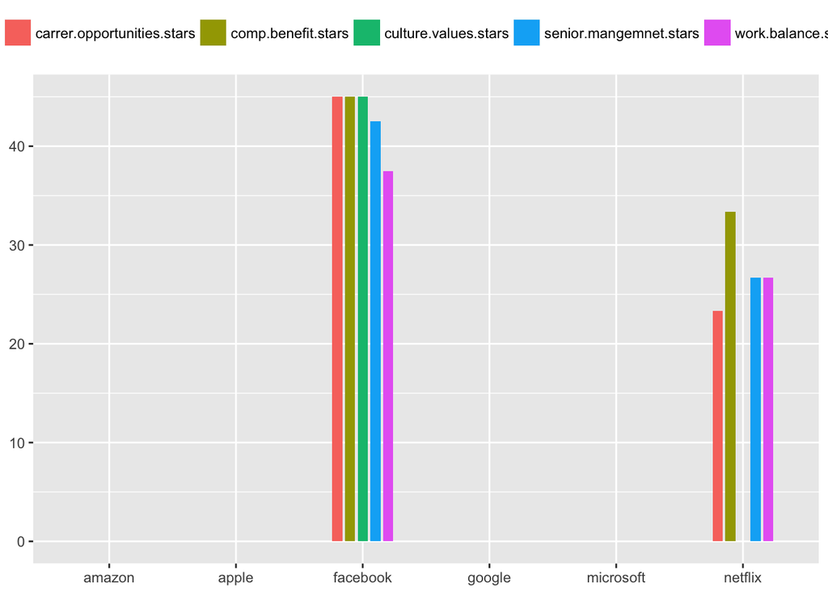

```r
ggplot(avgRatingByCompany, aes(Company, Rating)) + geom_bar(aes(fill = RatingType),
   width = 0.4, position = position_dodge(width=0.5), stat="identity") +
   theme(legend.position="top", legend.title =
   element_blank(),axis.title.x=element_blank(),
   axis.title.y=element_blank())
```